# QC Report

BamQCReportGenerator.Rmd written by: Mary B. O’Neill, Lab Member Generating Report:

This is meant to look for outlier samples run through the Pepperell Lab RGA Pipeline. Start by reading in the output from my bamQCcollate.py script (https://github.com/ONeillMB1/alignmentQC/). Note that this script pulls information for files you specifify from summary files produced by the program Qualimap (http://qualimap.bioinfo.cipf.es).

```
## 'data.frame':    76 obs. of  27 variables:
##  $ Sample   : chr  "ERR552445" "ERR551821" "ERR552940" "ERR552895" ...
##  $ meanCov  : num  42.4 42.8 30.6 44.2 56.8 ...
##  $ stdCov   : num  15.8 12.8 10.4 15.7 21.1 ...
##  $ meanMQ   : num  59.1 58.9 58.9 59 59 ...
##  $ perMapped: num  99 99.3 99.2 99 99.1 ...
##  $ perGen10X: num  96.6 98.2 97.4 96.9 97.9 ...
##  $ perGen15X: num  96.6 98.2 97.4 96.9 97.9 ...
##  $ perGen20X: num  93.5 96.3 88.1 94.3 96.5 ...
##  $ perGen30X: num  82.1 87.8 53.9 85.5 92.1 ...
##  $ dupRate  : num  23.7 36.1 30.2 19.7 34.8 ...
##  $ errRate  : num  0.01 0 0 0.03 0 0 0 0.01 0 0.01 ...
##  $ misMat   : int  1837255 572010 286056 6189266 690912 466098 489697 1437978 317856 891859 ...
##  $ numIns   : int  7729 3392 2323 28243 4895 3046 3630 2954 1454 2566 ...
##  $ insPer   : num  0.84 0.22 0.2 2.65 0.27 0.22 0.2 0.2 0.29 0.66 ...
##  $ numDel   : int  9526 4296 3093 34333 6842 3896 5023 4157 2151 3179 ...
##  $ delPer   : num  1.04 0.29 0.27 3.16 0.38 0.28 0.29 0.29 0.43 0.81 ...
##  $ homInd   : num  42.7 51.2 52 29.7 46.5 ...
##  $ meanIns  : num  7030 3395 3853 7655 7961 ...
##  $ medIns   : int  322 216 158 416 341 190 183 331 324 424 ...
##  $ stdIns   : num  120715 78258 86886 121767 127074 ...
##  $ GCper    : num  64.7 65 64.9 65.1 65.9 ...
##  $ A        : num  17.6 17.5 17.6 17.5 17.1 ...
##  $ C        : num  32.4 32.5 32.5 32.6 33 ...
##  $ G        : num  32.4 32.4 32.4 32.5 32.8 ...
##  $ T        : num  17.6 17.5 17.6 17.5 17.1 ...
##  $ N        : int  0 0 0 0 0 0 0 0 0 0 ...
##  $ Type     : chr  "RGA" "RGA" "RGA" "RGA" ...
```

There are 76 samples in the dataset.

## Mean Mapping Quality

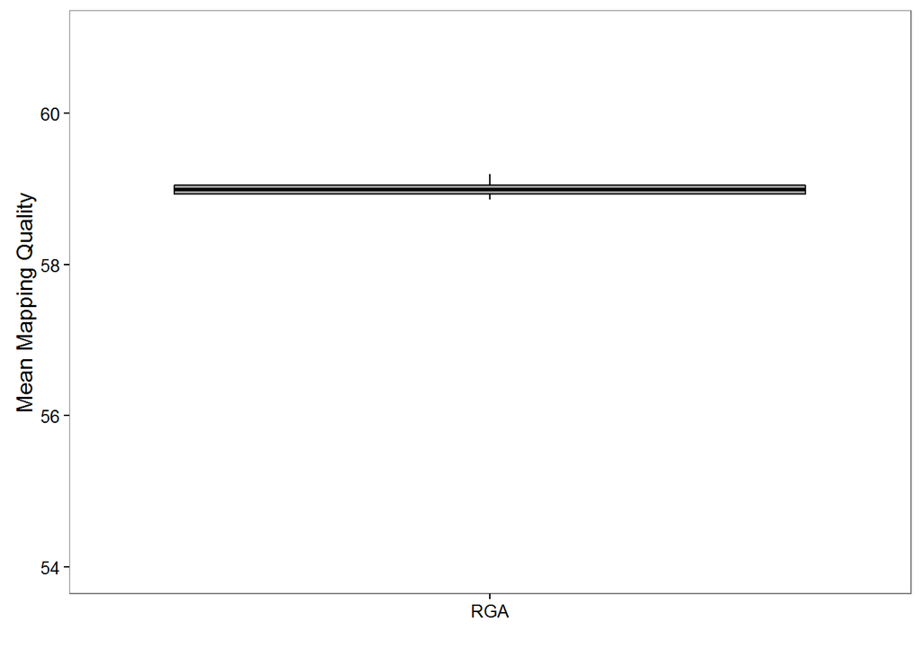

The mean mapping quality of the dataset is 58.9938158, with a range from 58.86 to 59.19. Throughout this document, outliers will refer to any samples falling above or below 1.5 times the interquartile range of the 1st or 3rd quartile of the data for the given statistic. Below is the info pertaining to the outliers (both high and low):

```
##  [1] Sample    meanMQ    meanCov   stdCov    perMapped perGen10X perGen15X
##  [8] perGen20X perGen30X GCper
## <0 rows> (or 0-length row.names)
```

# Mean Coverage

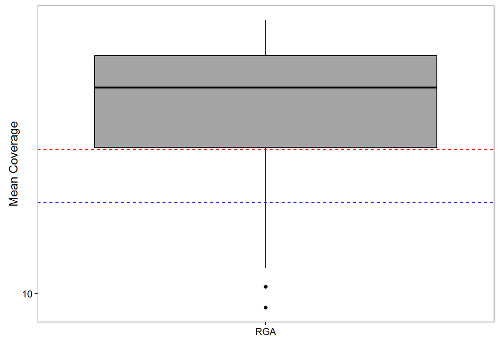

The dashed red line indicates an average coverage of 30X, the blue and average coverage of 20X. Note the log scale. Perhaps more important is the percentage of the reference genome covered by a given coverage.

# Percent Genome Covered at >= X

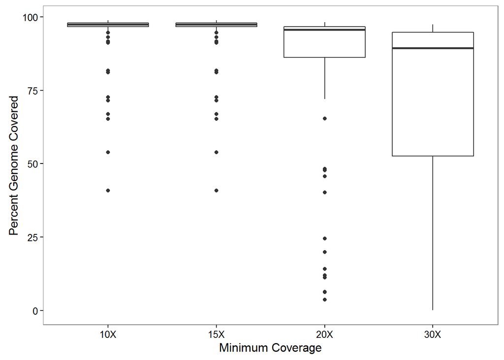

What is a good threshold?

# Relationship Between Mean Coverage and the Percent Genome Covered By X

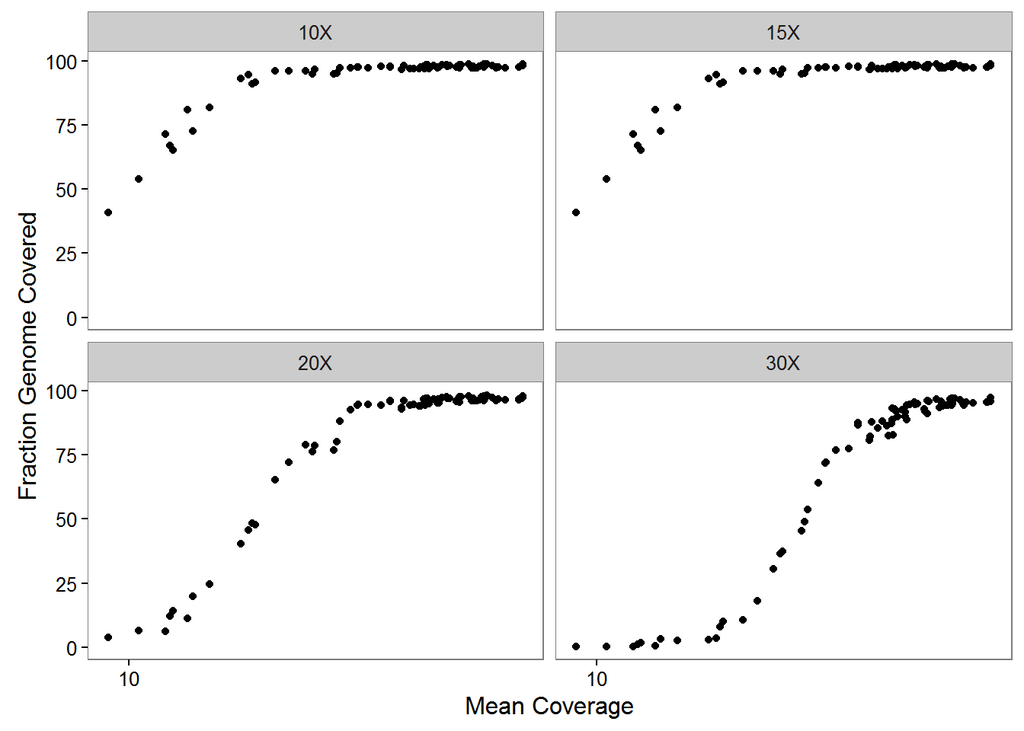

Again note that the x-axis is on a log scale.

Below is the info pertaining to the outliers for the 10X threshold:

```
##       Sample meanMQ meanCov stdCov perMapped perGen10X perGen15X perGen20X
## 33 ERR551983  59.04    8.98   5.20     98.98     40.91     40.91      3.71
## 60 ERR551979  58.99   10.54   5.56     99.21     53.93     53.93      6.37
## 62 ERR552669  59.05   12.62   6.66     99.39     65.30     65.30     14.17
## 22 ERR552690  58.93   12.43   6.18     99.08     66.89     66.89     12.02
## 18 ERR551943  58.94   12.14   4.84     98.12     71.51     71.51      6.32
## 30 ERR551981  58.99   14.03   7.21     98.78     72.61     72.61     19.95
## 20 ERR550779  59.06   13.63   5.16     99.22     81.08     81.08     11.30
## 9  ERR551980  58.99   15.33   6.78     99.00     81.70     81.70     24.52
## 10 ERR553303  58.93   19.24   7.67     99.53     91.15     91.15     48.29
## 54 ERR552670  58.93   19.53   7.86     99.40     91.65     91.65     47.76
## 40 ERR551558  59.08   18.07   6.16     99.33     93.10     93.10     40.25
## 29 ERR551806  59.03   18.85   6.09     99.30     94.62     94.62     45.72
##    perGen30X GCper
## 33      0.23 64.58
## 60      0.38 64.74
## 62      1.75 64.48
## 22      1.02 64.68
## 18      0.11 65.13
## 30      3.10 64.55
## 20      0.56 65.20
## 9       2.71 64.56
## 10      7.96 65.47
## 54     10.17 64.55
## 40      2.85 65.16
## 29      3.51 65.29
```

## Percent of Reads Mapped

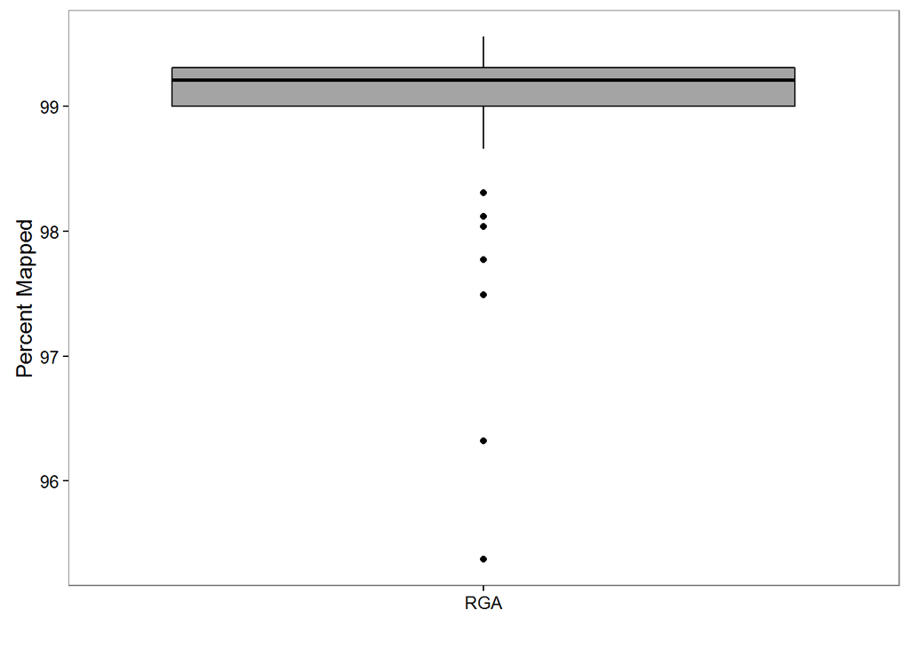

This statistic is a good proxy for possible contamination and/or high divergence from the reference.

Below is the info pertaining to outliers:

```
##       Sample meanMQ meanCov stdCov perMapped perGen10X perGen15X perGen20X
## 52 ERR552689  58.87   57.53  23.03     95.37     97.39     97.39     95.54
## 34 ERR551982  58.91   29.61  14.20     96.32     94.83     94.83     76.99
## 38 ERR553156  58.86   47.53  17.63     97.49     97.28     97.28     94.88
## 8  ERR551167  59.01   39.88  10.87     97.77     97.78     97.78     96.07
## 67 ERR550940  58.93   61.27  23.47     98.04     97.40     97.40     96.08
## 18 ERR551943  58.94   12.14   4.84     98.12     71.51     71.51      6.32
## 68 ERR550941  58.97   69.76  27.32     98.31     97.32     97.32     96.13
##    perGen30X GCper
## 52     91.26 64.36
## 34     45.40 64.24
## 38     87.34 64.52
## 8      87.44 65.26
## 67     93.50 64.65
## 18      0.11 65.13
## 68     94.31 64.77
```

Lets look at the relationship between percent mapped and mean coverage.

# Relationship Between Percentage of Reads Mapped and the Mean Coverage

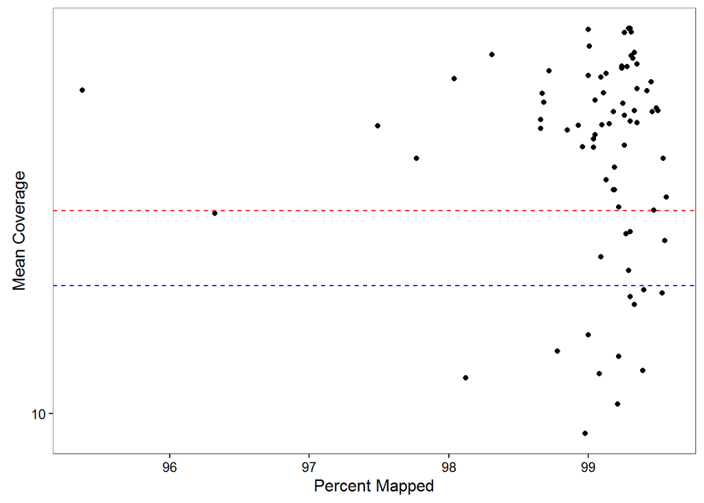

The red dotted line corresponds to a mean coverage of 30X and the blue a mean coverage of 20X.

## Duplication Rate

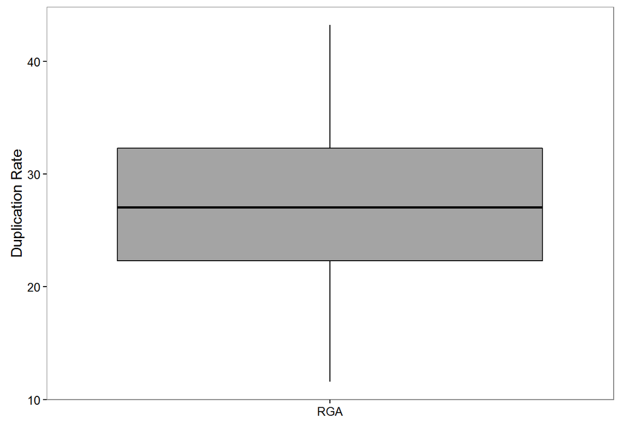

How should we interpret the duplication rate? We mark duplicates in our pipeline, so I am less concerned about this statistic.

## GC Percentage

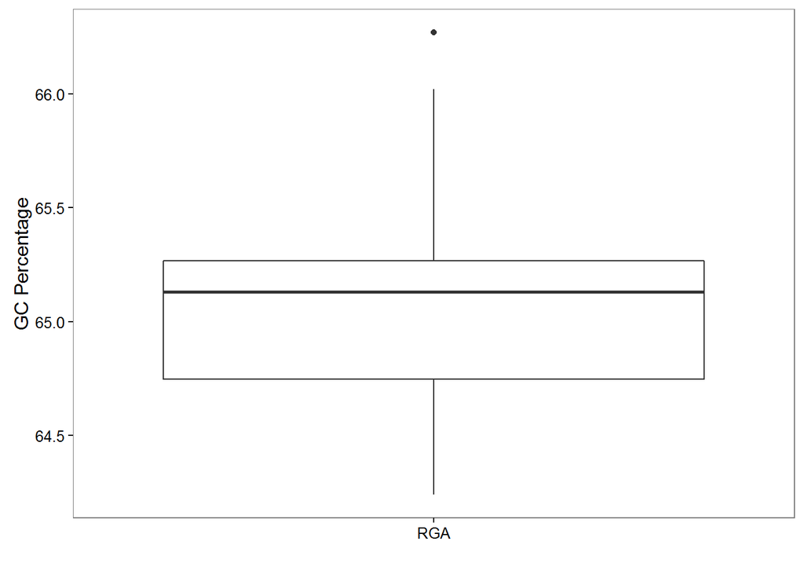

How much spread is acceptable in terms of GC content? Does it vary by lineage/clade? You will need to incorporate more data to look at this kind of thing.

# Percent Reads Mapped vs GC Percentage

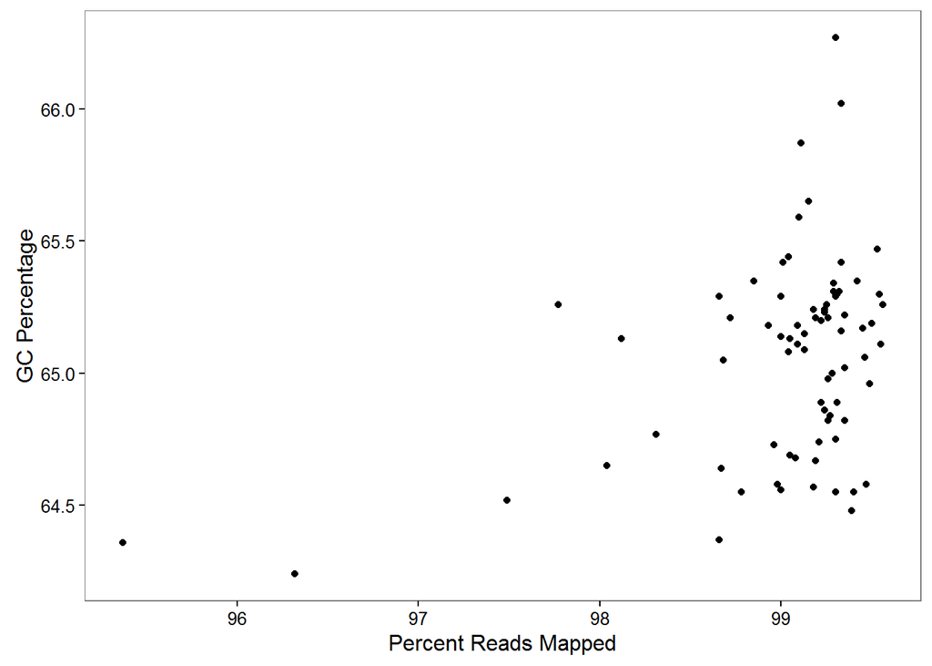

## Nucleotide Content

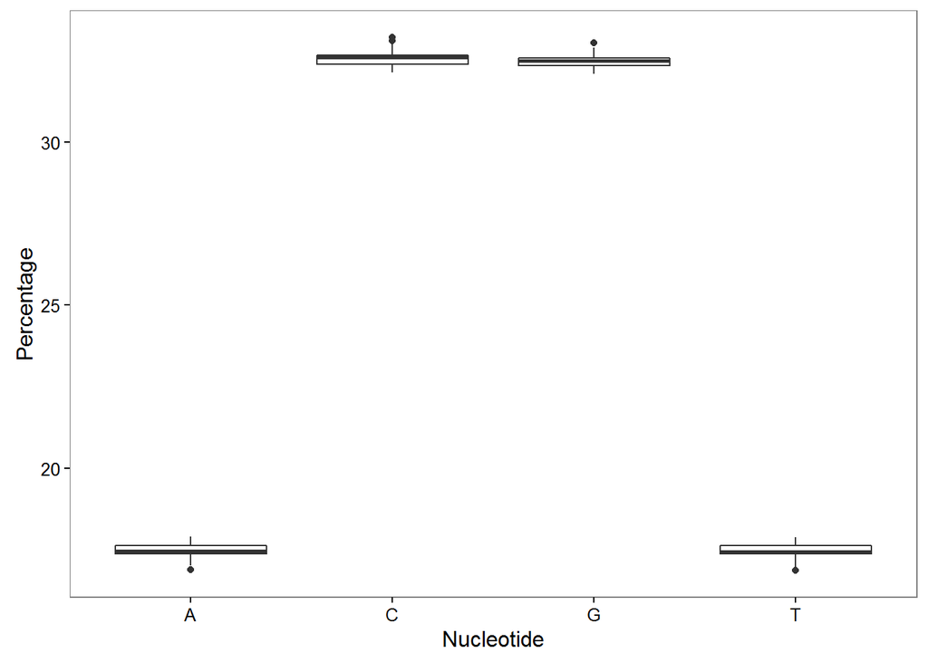

The G-C content should be the about the same for each sample, so maybe I can identify some outliers by plotting the G vs C content and T vs A.

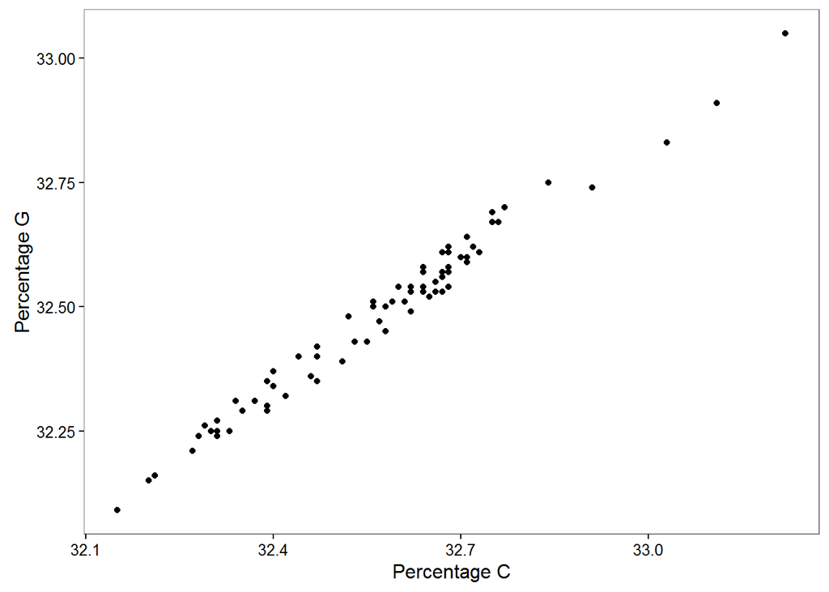

Lets move on and do the same for A vs T.

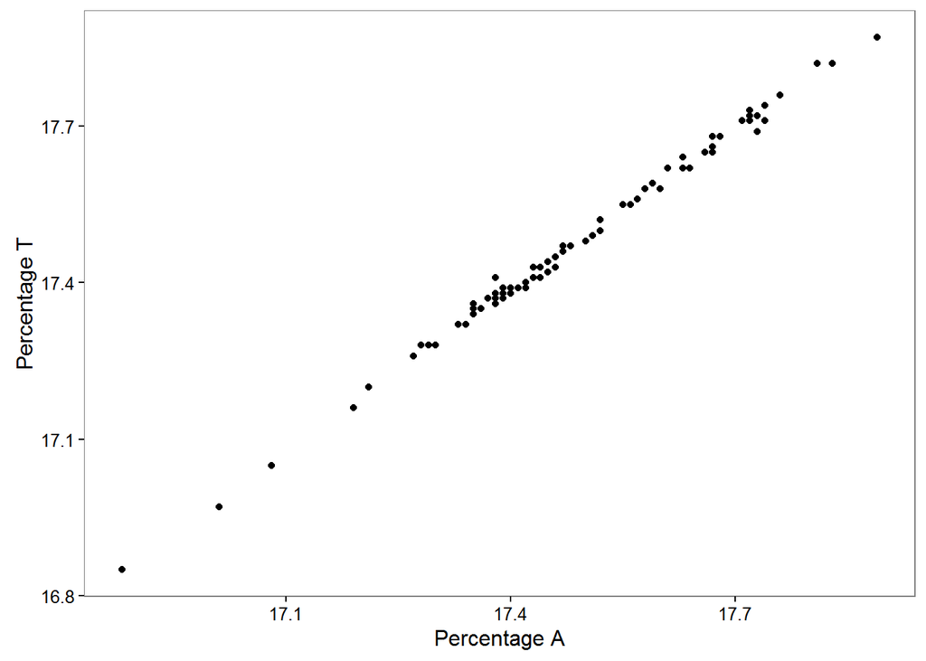

## Mismatches

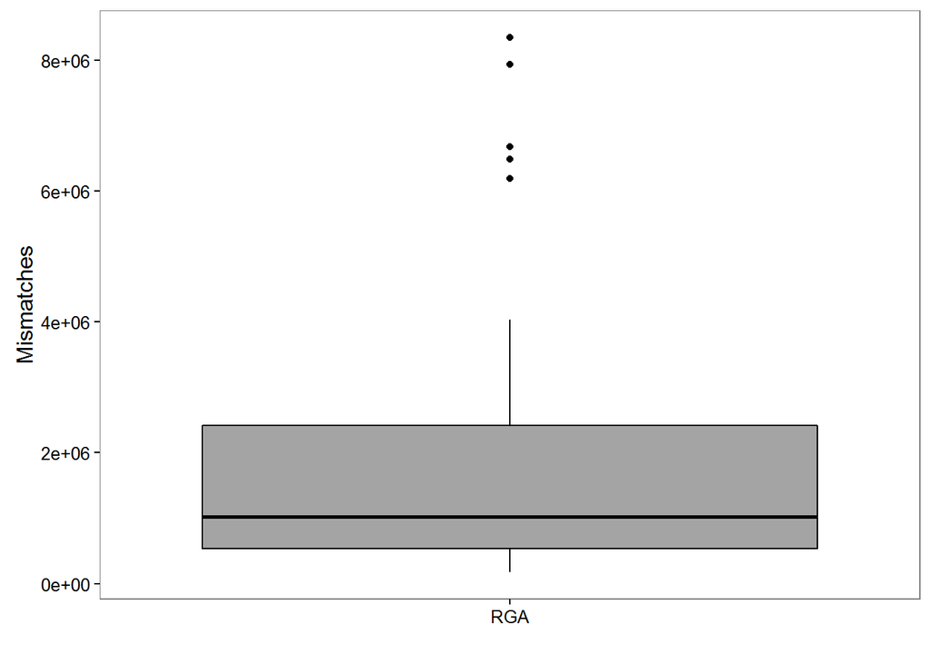

# Relationship Between Mismatches and Mean Coverage

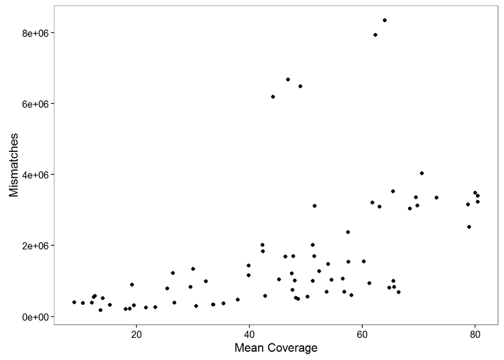

You can imagine that if the error rate is constant, as you increase coverage you are bound to have more incorrecltly called bases, but our power to detect such even will increase. Perhaps this should be normalized by the total number of bases (mapped).

# Have fun exploring your data!